# Exploratory Analysis on Relationship between Parent Education and Children Success UpMath!

Maimul Hoque (S2142027) - Group Leader

Aainaa Nadia Binti Mohammed Hashim (S2043599)

Noel Ng Fong Nian (S2142165)

Rose Tiong (S2123103)

Wong Ann Li (S2148268)

2022-06-20

# Introduction

- As the saying goes, parents are children’s first teacher in this world. We are interested in knowing how parents can influence their children, in terms of if the correlation occurs between parents’ education background and children’s academic performance. We are keen to know if the statement mentioned above makes sense.
- The analysis was conducted on the Kaggle dataset (Student Alcohol Consumption | Kaggle). https://www.kaggle.com/datasets/uciml/student-alcohol-consumption
- EDA and App Building were conducted by using R studio.

# Up Maths! – App Description

### Up Maths! User Interface

[figure not shown]

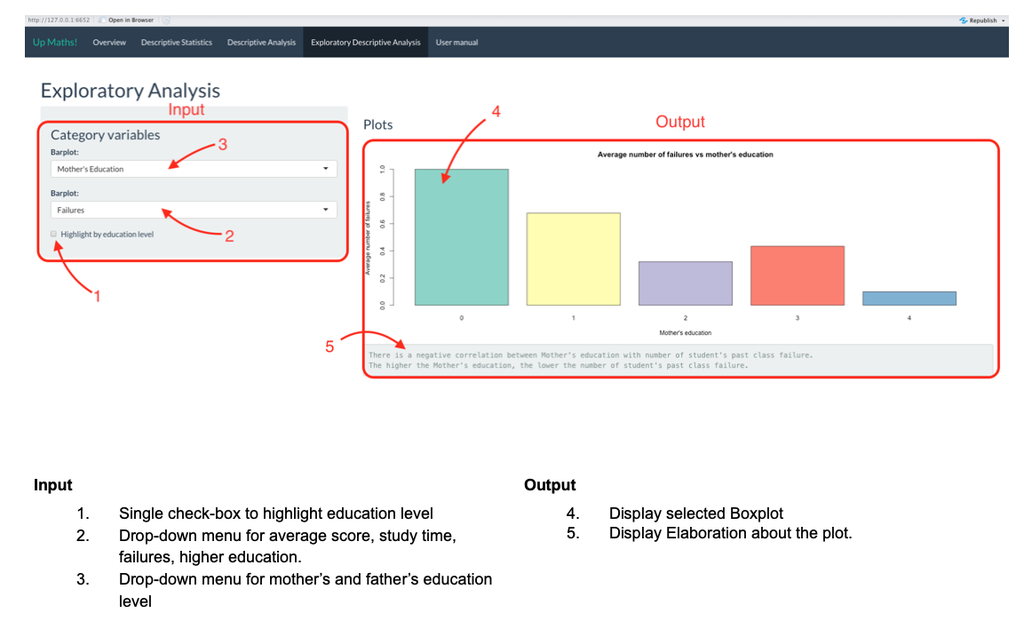

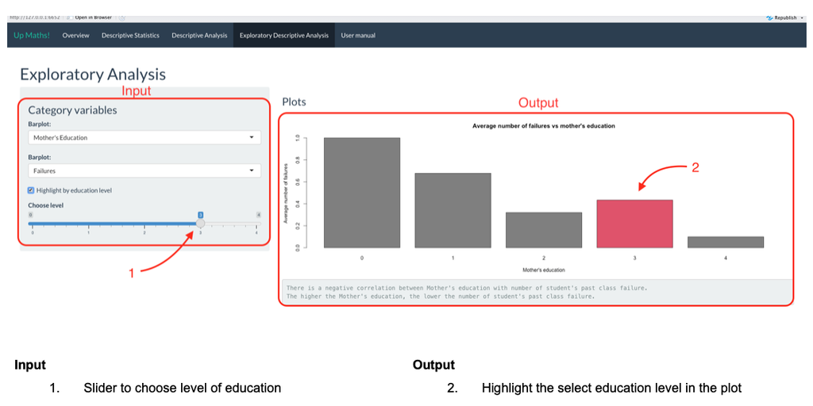

# Design Thinking

- Phase 1: Empathize – Understood the need of the schools, teachers and parents in identifying what parents can do to help children perform better in schools.
- Phase 2: Define – Set our goal: represent the kids to inform their parents that their education level influence the kids’ school grade too.
- Phase 3: In order to let the users understood more about our topic, we prepared an infographic at overview of Shiny App to attract their attention.

# Summary of Experience

- In this is our first experience in learning to deploy our Up Math! ShinyApp and successfully deployed within a short period (1.5weeks).
- The shiny App’s dashboard is generated with three components: user interface object, server function, and call to the shinyApp function.
- Besides that, data visualization and exploratory data analysis are performed in Rstudio.
- In the shinyApp, the user needs to take a long time to load the graphs themselves; thus, the user wouldn’t be satisfied when using the App. Therefore, we have shown the charts based on the inputs selected by the user. For example, the user chooses the available dependent and independent variables and shows the graph within seconds.

Up Maths! app link: https://iqeiaz-0i0.shinyapps.io/ShinyApp7001/

R codes and supporting document on Github: https://github.com/maimul/WQD7001/tree/main/ShinyApp7001

# Discuss the current issues and challenges facing Data Science today.

1. Data Security:
   1. An important aspect as it includes al security measures and tools used in analytics and data processes
   2. Data systems, ransomware and theft exists nowadays which make it important to implement data security
2. Lack of clarity:
   1. One needs to investigate and understand the issue properly
   2. Lead to getting accurate insights that is related to the business problems
3. Data-driven culture:
   1. This culture needs to be implemented in organisation
   2. The combination of big data widely available in organisation but without desired support will not result in any insightful outcomes
   3. Data needs to be utilised to a good use with the combination of supports obtained from organisations
   4. Employees need to unite over shared mission to improve the organisation
4. Data source:
   1. Good dataset does not always mean a right dataset
   2. We need to obtain dataset that can actually answer the problems we have
   3. This way, we could achieve valuable insights from it
5. Lack of experienced data scientists:
   1. Organisations need to provide additional training
   2. It helps in upskilling data scientists they have in the organisation to perform better in solving business problems